# Predicting the Whole Transcriptome

Amir Asiaee

2023-10-25

```r
knitr:::opts_chunk$set(fig.path="../results/mirfigs/")
knitr::opts_chunk$set(fig.width=12)
```

# Getting Started

Here, we continue to show that our selected features (TFs and miRs) are bilogically informative. We show that we can explain the variation of the whole transcriptome using only 47 measurements!

```r
rm(list=ls())
source("00-paths.R")

load(file.path(paths$clean, 'xena-tcga.Rda'))
load(file.path(paths$scratch, "xena-tcga-mir-medoid.Rda"))
load(file.path(paths$scratch, "xena-tcga-tf-medoid.Rda"))
mRNARest <- as.matrix(tcga$mrna)
# Removing constant genes to prevent Inf R^2
mRNAs_sd <- apply(mRNARest, 1, sd)
mRNARest <- mRNARest[mRNAs_sd != 0, ]

cancerType <- tcga$tissue

dim(mirMedoid)
```

```
## [1] 10013    28
```

```r
dim(tfMedoid)
```

```
## [1] 10013    19
```

```r
dim(mRNARest)
```

```
## [1] 19053 10013
```

```r
dev_mode <- T

rm(tcga, mRNAs_sd)
```

# R2 Joint Models

By joint model, we mean a model that uses both TFs and miRNAs

```r
compute_and_save_outcome_variation <- function(f, outcome) {
  requireNamespace("ClassComparison", quietly = TRUE)
  if (file.exists(f)) {
    load(f)
  } else {
    N <- ncol(outcome)
    dmean <- matrixMean(outcome)
    dvar <- as.vector(matrixVar(outcome, dmean))
    save(N, dvar, file = f)
  }
  return(list(N = N, dvar = dvar))
}

f <- file.path(paths$scratch, "xena-tcga-mRNA-outcome-constants.Rda")
constants <- compute_and_save_outcome_variation(f, mRNARest)

rm(f, const_genes, dmean, i, myZero, results)
```

## Tissue-Agnostic Model

Here we regress each (of ~20,000) mRNA into miR and TF mediods. So we have 20,000 regression problems, 10,000 samples, and 47 features.

```r
library(ClassComparison)
```

```
## [1] "Percentage of R2 more than the threshold 0 is 1"
```

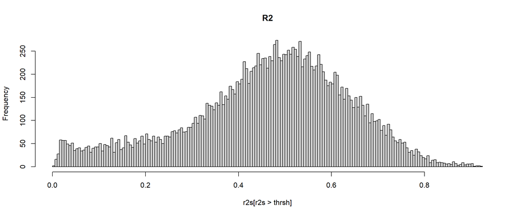

```r
compute_agnostic_model <- function(f_path, g_path, X1, X2, Y, saveAs) {
  if (file.exists(f_path) && file.exists(g_path)) {
    load(f_path)
    load(g_path)
  } else {
    requireNamespace("ClassComparison", quietly = TRUE)
    agnostic_mlm <- MultiLinearModel(Y ~ ., cbind(X1, X2), Y) #It has intercept internally
    agnostic_R <- Y - t(agnostic_mlm@predictions)
    save(agnostic_R, agnostic_mlm, file = g_path)
  }
  return(list(R = agnostic_R, mlm = agnostic_mlm))
}


f <- file.path(paths$scratch, "xena-tcga-agnostic-mlm.Rda")
g <- file.path(paths$scratch, "xena-tcga-agnostic-residuals.Rda")
agnostic <- compute_agnostic_model(f, g, tfMedoid, mirMedoid, mRNARest)
saveAs <- "xena-tcga-agnostic-R2"
agnostic_r2s <- histsR2(agnostic$R, saveAs, constants, replace = dev_mode)
```

We clean up in a separate block:

```r
rm(agnostic, r2s, saveAs, ssres, f, g)
gc()
```

```
##             used   (Mb) gc trigger   (Mb)   max used    (Mb)
## Ncells    980950   52.4    1548114   82.7    1548114    82.7
## Vcells 193167298 1473.8 1125115191 8584.0 1406391557 10730.0
```

## Tissue-Aware Model

An intelligent way of bringing in the tissue into the prediction is to have a separate prediction per tissue. We first mean zero the output (using all genes) and then fit a per tissue model (fit the the residuals). This is equivalent to fit a global linear model first and then fit the residuals with a linear model per tissue.

First let initialize:

```r
magicThresh <- 50  #We have 47 features, so at least we need 50 samples.
f <- file.path(paths$scratch, "xena-tcga-mean0mRNA.Rda")
if (file.exists(f)) {
  load(f)
} else {
  mean0mRNA <- sweep(mRNARest, 1, apply(mRNARest, 1, mean))
  save(mean0mRNA,  file = f)
}
rm(f)
```

Now, fit one linear model per tissue. For low sample tissues, the model is just an intercept. Some features are constants for some tissues, we remove them to avoid singularity:

```r
library(ClassComparison)
aware_residuals <- matrix(0, nrow = nrow(mean0mRNA), ncol = ncol(mean0mRNA))
f <- file.path(paths$scratch, "xena-tcga-tissue-aware-mlm.Rda")
g <- file.path(paths$scratch, "xena-tcga-tissue-aware-residuals.Rda")

if (file.exists(f)) {
  load(f)
  load(g)
} else {

  aware_mlm_list <- list()
  low_sample_tissue <- c() #what type has insufficient sample for MLM
  X <- cbind(tfMedoid, mirMedoid)
  variable_features_in_tissue <- matrix(T, length(unique(cancerType)), ncol(X))
  rownames(variable_features_in_tissue) <- unique(cancerType)

  for(type in unique(cancerType)){
    print(paste("Fitting", type))
    Ts <- (cancerType == type) #Tissue Selector
    if(sum(Ts) < magicThresh){ #Per-tissue average is our predictor
      tissue_mrna_mean <- apply(mean0mRNA[,Ts], 1, mean)
      aware_residuals[,Ts] <- mean0mRNA[,Ts] - tissue_mrna_mean
      aware_mlm_list[[type]] <- tissue_mrna_mean #just an intercept
      low_sample_tissue <- c(low_sample_tissue, TRUE)
    } else{
      newX <- X[Ts,]
      #Remove constant features to avoid singularity
      variable_features <- apply(newX, 2, min) != apply(newX, 2, max) #none degenerate (non-constant) features
      variable_features_in_tissue[type,] <- variable_features
      newX <- newX[, variable_features]
      aware_mlm <- MultiLinearModel(Y ~ ., newX, mean0mRNA[,Ts])
      aware_residuals[,Ts] <- mean0mRNA[,Ts] - t(aware_mlm@predictions)
      aware_mlm_list[[as.character(type)]] <- aware_mlm
      low_sample_tissue <- c(low_sample_tissue, FALSE)
    }

  }
  # Checking low sample tissues:
  print(paste("Low sample cancer types", unique(cancerType)[low_sample_tissue]))
  # Sanity check
  table(cancerType)

  print(paste("Do we have any constant feature per tissue?",
              ifelse(sum(apply(variable_features_in_tissue, 1, sum) != ncol(tfMedoid) + ncol(mirMedoid)) > 0, "Yes", "No")))

  save(aware_mlm_list,  file = f)
  save(aware_residuals, file = g)
}
rm(f, g)
gc()
```

```
##             used   (Mb) gc trigger    (Mb)   max used    (Mb)
## Ncells    983405   52.6    1548114    82.7    1548114    82.7
## Vcells 797040480 6081.0 1350218229 10301.4 1406391557 10730.0
```

```
## [1] "Percentage of R2 more than the threshold 0 is 1"
```

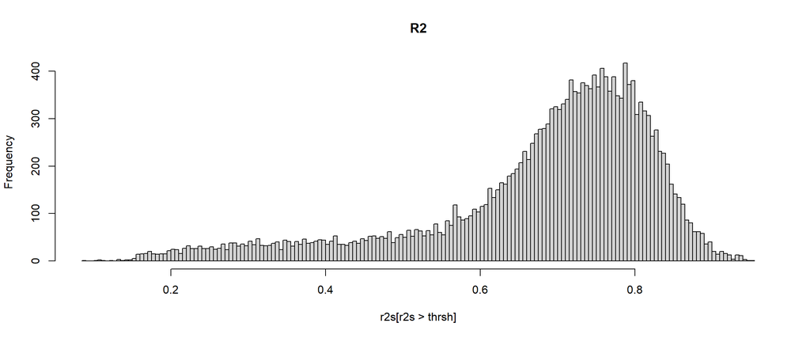

```r
saveAs <- "xena-tcga-aware-R2"
aware_r2s <- histsR2(aware_residuals, saveAs, constants, replace = dev_mode)
```

We clean up in a separate block.

```r
rm(tfMedoid, mirMedoid, aware_mlm_list, aware_residuals, mean0mRNA, magicThresh,
   variable_features, variable_features_in_tissue, low_sample_tissue,
   dvar, newX, type, Ts, saveAs, X, tissue_mrna_mean, aware_mlm, cohorts,
   mRNARest, N, cancerType, tcga)
gc()
```

```
##           used (Mb) gc trigger   (Mb)   max used    (Mb)
## Ncells  971015 51.9    1548114   82.7    1548114    82.7
## Vcells 1869089 14.3 1080174584 8241.1 1406391557 10730.0
```

# BetaMixture Model

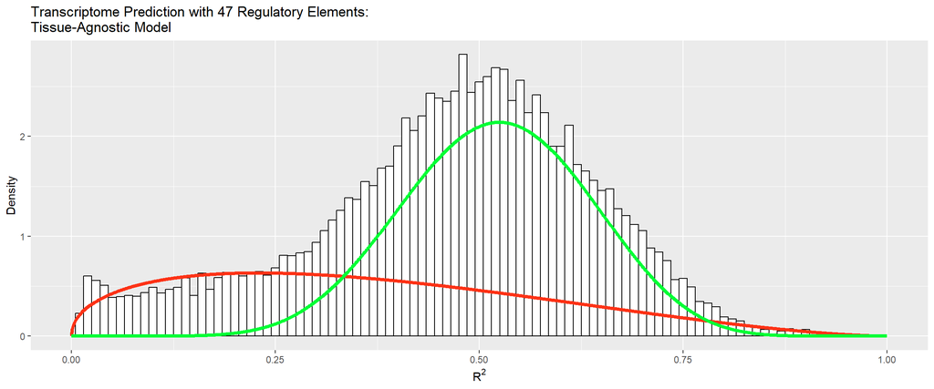

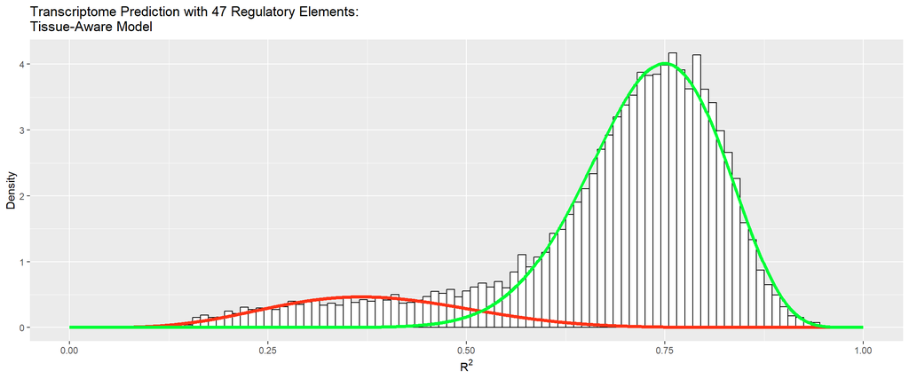

# Appendix